# OPA Data Exploratory Analysis

Team 6

2026-04-15

## Data Sources

- **Main table**: `musa5090s25-team6.core.opa_properties` (via BigQuery)
- **Supplementary table**: `musa5090s25-team6.core.opa_assessments`
- **Original dataset**: [Philadelphia Properties and Assessment History - OpenDataPhilly](https://opendataphilly.org/dataset/opa-property-assessments)

## 1. Load Required Packages

```r
library(tidyverse)
library(skimr)
library(corrplot)
library(ggplot2)
library(lubridate)
library(scales)
library(gridExtra)
```

## 2. Connect to BigQuery and Load Data

```r
# Load data from local CSV exported from BigQuery
df_raw <- read.csv("opa_properties.csv")

cat("Raw row count:", nrow(df_raw), "\n")
```

```
## Raw row count: 581058
```

```r
cat("Number of columns:", ncol(df_raw), "\n")
```

```
## Number of columns: 18
```

## 3. Data Cleaning

### 3.1 Filter Out Anomalously Low Sale Prices

Properties with very low sale prices (e.g. $1) are likely family transfers or administrative transactions and are not representative of true market value.

```r
# Check the price distribution before filtering
summary(df_raw$sale_price)
```

```
##      Min.   1st Qu.    Median      Mean   3rd Qu.      Max.
##         0         1     59000    325155    190000 968000000
```

```r
# Remove records where sale_price <= 100
df_clean <- df_raw |>
  filter(
    sale_price > 100,
    sale_price < 2000000
  )

cat("Rows after filtering low prices:", nrow(df_clean), "\n")
```

```
## Rows after filtering low prices: 406815
```

```r
cat("Records removed:", nrow(df_raw) - nrow(df_clean), "\n")
```

```
## Records removed: 174243
```

### 3.2 Filter Out Bundle Sales

Properties sold on the exact same day at the exact same price are likely part of a bundle sale. In those cases, `sale_price` represents the price of the entire bundle, not any individual property.

```r
# Identify bundle sales: same sale_date AND same sale_price
df_clean <- df_clean |>
  group_by(sale_date, sale_price) |>
  mutate(bundle_count = n()) |>
  ungroup() |>
  filter(bundle_count == 1) |>
  select(-bundle_count)

cat("Rows after filtering bundle sales:", nrow(df_clean), "\n")
```

```
## Rows after filtering bundle sales: 323028
```

### 3.3 Type Conversion and Derived Features

```r
df_clean <- df_clean |>
  mutate(
    # --- Date features ---
    sale_date = as.Date(sale_date),
    sale_year = year(sale_date),
    days_since_sale = as.numeric(Sys.Date() - sale_date),

    # --- Derived numeric features ---
    property_age = 2025 - year_built,
    log_sale_price = log(sale_price),
    log_livable_area = log(total_livable_area + 1),

    # --- Fix anomalous property age ---
    property_age = ifelse(property_age < 0 | property_age > 200, NA, property_age),

    # --- Condition fields to numeric ---
    exterior_condition = as.numeric(exterior_condition),
    interior_condition = as.numeric(interior_condition),

    # --- Simplify zoning into broad categories ---
    zoning_group = case_when(
      str_starts(zoning, "RM") ~ "Residential_Multi",
      str_starts(zoning, "RSA") | str_starts(zoning, "RSD") ~ "Residential_Single",
      str_starts(zoning, "CMX") | str_starts(zoning, "CA") ~ "Commercial",
      str_starts(zoning, "I") ~ "Industrial",
      TRUE ~ "Other"
    ),

    # --- zip_code as character for encoding ---
    zip_code = as.character(zip_code)
  ) |>
  # --- Remove remaining anomalous values ---
  filter(
    sale_price > 100,
    sale_price < 2000000,
    total_livable_area > 0 | is.na(total_livable_area)
  )
```

## 4. Exploratory Data Analysis

### 4.1 Target Variable Distribution: sale_price

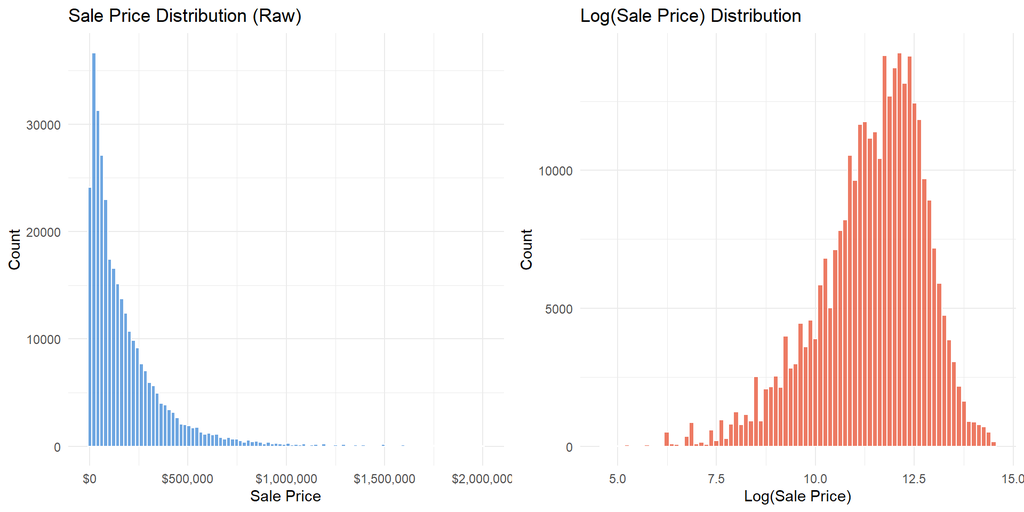

```r
p1 <- ggplot(df_clean, aes(x = sale_price)) +
  geom_histogram(bins = 100, fill = "#4A90D9", color = "white", alpha = 0.8) +
  scale_x_continuous(labels = dollar_format()) +
  labs(title = "Sale Price Distribution (Raw)",
       x = "Sale Price", y = "Count") +
  theme_minimal()

p2 <- ggplot(df_clean, aes(x = log_sale_price)) +
  geom_histogram(bins = 80, fill = "#E8593C", color = "white", alpha = 0.8) +
  labs(title = "Log(Sale Price) Distribution",
       x = "Log(Sale Price)", y = "Count") +
  theme_minimal()

grid.arrange(p1, p2, ncol = 2)
```

### 4.2 Time Trend: Sale Year vs Median Sale Price

More recent sales are likely to carry a stronger signal for current property values.

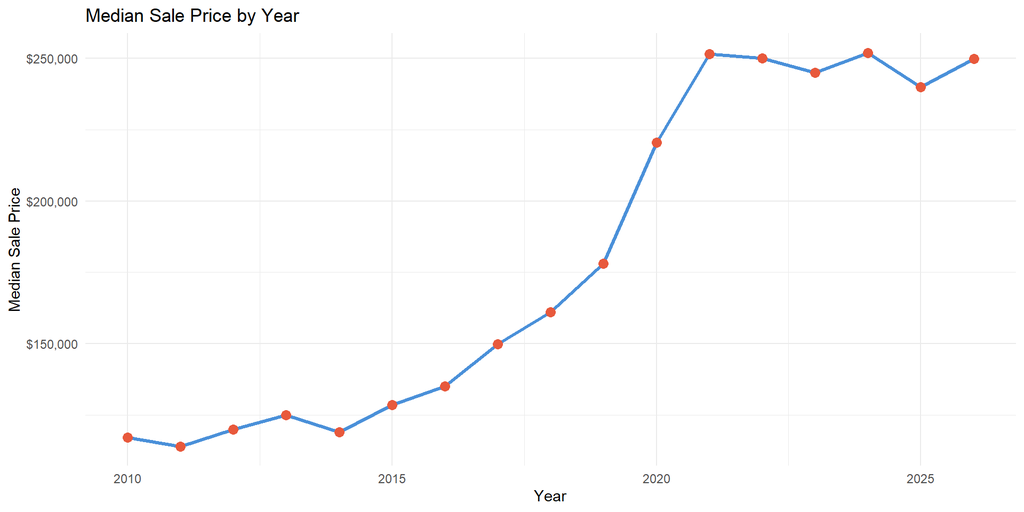

```r
df_clean |>
  filter(sale_year >= 2010) |>
  group_by(sale_year) |>
  summarise(median_price = median(sale_price, na.rm = TRUE), .groups = "drop") |>
  ggplot(aes(x = sale_year, y = median_price)) +
  geom_line(color = "#4A90D9", size = 1.2) +
  geom_point(color = "#E8593C", size = 3) +
  scale_y_continuous(labels = dollar_format()) +
  labs(title = "Median Sale Price by Year",
       x = "Year", y = "Median Sale Price") +
  theme_minimal()
```

### 4.3 Total Livable Area vs Sale Price

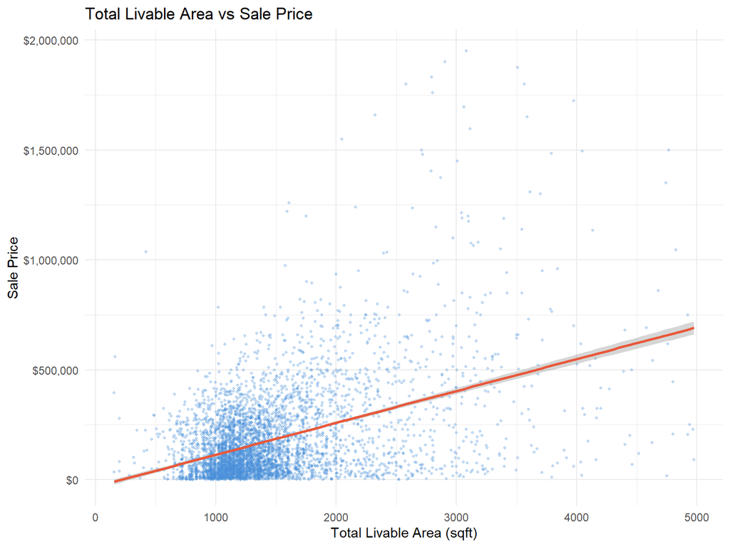

```r
df_clean |>
  filter(total_livable_area > 0, total_livable_area < 5000) |>
  sample_n(min(5000, nrow(df_clean))) |>
  ggplot(aes(x = total_livable_area, y = sale_price)) +
  geom_point(alpha = 0.3, color = "#4A90D9", size = 0.8) +
  geom_smooth(method = "lm", color = "#E8593C", se = TRUE) +
  scale_y_continuous(labels = dollar_format()) +
  labs(title = "Total Livable Area vs Sale Price",
       x = "Total Livable Area (sqft)", y = "Sale Price") +
  theme_minimal()
```